# Heart Disease

Stephen Wang

16/09/2019

My dad, like every other Asian father, had big hopes for me to become a doctor. But after watching Scrubs and it’s soul-crushing depiction of medical practitioners, I quickly bid that dream farewell. This project is both a means of redeeming myself and putting into practice what I learnt from the previous forest fire project and the statistical theory I am learning right now.

The goal of this study is to investigate if there are any factors that is a clear indication of cardiovascular health.

The data was retrieved from https://www.kaggle.com/ronitf/heart-disease-uci and https://archive.ics.uci.edu/ml/datasets/heart+Disease in which the data was gathered from the Cleveland patient database. Each patient has a chest pain type (explained below).

As usual, our plan of attack: (1) understand the variables in our dataset (2) clean and manipulate the data (3) statistical analysis

```r
heart_disease <- read_csv('heart.csv')
dim(heart_disease)
```

```
## [1] 303  14
```

```r
head(heart_disease, 10)
```

```
## # A tibble: 10 x 14
##      age   sex    cp trestbps  chol   fbs restecg thalach exang oldpeak
##    <dbl> <dbl> <dbl>    <dbl> <dbl> <dbl>   <dbl>   <dbl> <dbl>   <dbl>
##  1    63     1     3      145   233     1       0     150     0     2.3
##  2    37     1     2      130   250     0       1     187     0     3.5
##  3    41     0     1      130   204     0       0     172     0     1.4
##  4    56     1     1      120   236     0       1     178     0     0.8
##  5    57     0     0      120   354     0       1     163     1     0.6
##  6    57     1     0      140   192     0       1     148     0     0.4
##  7    56     0     1      140   294     0       0     153     0     1.3
##  8    44     1     1      120   263     0       1     173     0     0
##  9    52     1     2      172   199     1       1     162     0     0.5
## 10    57     1     2      150   168     0       1     174     0     1.6
## # … with 4 more variables: slope <dbl>, ca <dbl>, thal <dbl>, target <dbl>
```

```r
tail(heart_disease, 10)
```

```
## # A tibble: 10 x 14
##      age   sex    cp trestbps  chol   fbs restecg thalach exang oldpeak
##    <dbl> <dbl> <dbl>    <dbl> <dbl> <dbl>   <dbl>   <dbl> <dbl>   <dbl>
##  1    67     1     2      152   212     0       0     150     0     0.8
##  2    44     1     0      120   169     0       1     144     1     2.8
##  3    63     1     0      140   187     0       0     144     1     4
##  4    63     0     0      124   197     0       1     136     1     0
##  5    59     1     0      164   176     1       0      90     0     1
##  6    57     0     0      140   241     0       1     123     1     0.2
##  7    45     1     3      110   264     0       1     132     0     1.2
##  8    68     1     0      144   193     1       1     141     0     3.4
##  9    57     1     0      130   131     0       1     115     1     1.2
## 10    57     0     1      130   236     0       0     174     0     0
## # … with 4 more variables: slope <dbl>, ca <dbl>, thal <dbl>, target <dbl>
```

```r
colSums(is.na(heart_disease))
```

```
##      age      sex       cp trestbps     chol      fbs  restecg  thalach
##        0        0        0        0        0        0        0        0
##    exang  oldpeak    slope       ca     thal   target
##        0        0        0        0        0        0
```

```r
summary(heart_disease)
```

```
##       age             sex               cp           trestbps
##  Min.   :29.00   Min.   :0.0000   Min.   :0.000   Min.   : 94.0
##  1st Qu.:47.50   1st Qu.:0.0000   1st Qu.:0.000   1st Qu.:120.0
##  Median :55.00   Median :1.0000   Median :1.000   Median :130.0
##  Mean   :54.37   Mean   :0.6832   Mean   :0.967   Mean   :131.6
##  3rd Qu.:61.00   3rd Qu.:1.0000   3rd Qu.:2.000   3rd Qu.:140.0
##  Max.   :77.00   Max.   :1.0000   Max.   :3.000   Max.   :200.0
##       chol            fbs            restecg          thalach
##  Min.   :126.0   Min.   :0.0000   Min.   :0.0000   Min.   : 71.0
##  1st Qu.:211.0   1st Qu.:0.0000   1st Qu.:0.0000   1st Qu.:133.5
##  Median :240.0   Median :0.0000   Median :1.0000   Median :153.0
##  Mean   :246.3   Mean   :0.1485   Mean   :0.5281   Mean   :149.6
##  3rd Qu.:274.5   3rd Qu.:0.0000   3rd Qu.:1.0000   3rd Qu.:166.0
##  Max.   :564.0   Max.   :1.0000   Max.   :2.0000   Max.   :202.0
##      exang           oldpeak         slope             ca
##  Min.   :0.0000   Min.   :0.00   Min.   :0.000   Min.   :0.0000
##  1st Qu.:0.0000   1st Qu.:0.00   1st Qu.:1.000   1st Qu.:0.0000
##  Median :0.0000   Median :0.80   Median :1.000   Median :0.0000
##  Mean   :0.3267   Mean   :1.04   Mean   :1.399   Mean   :0.7294
##  3rd Qu.:1.0000   3rd Qu.:1.60   3rd Qu.:2.000   3rd Qu.:1.0000
##  Max.   :1.0000   Max.   :6.20   Max.   :2.000   Max.   :4.0000
##       thal           target
##  Min.   :0.000   Min.   :0.0000
##  1st Qu.:2.000   1st Qu.:0.0000
##  Median :2.000   Median :1.0000
##  Mean   :2.314   Mean   :0.5446
##  3rd Qu.:3.000   3rd Qu.:1.0000
##  Max.   :3.000   Max.   :1.0000
```

There are 303 rows and 14 columns with no null values.

Two things that immediately come to my attention: - many of these variables are categorical denoted by numbers so we need to change the types of these columns - ‘target’ is most likely going to be our dependent variable as that is related to this study’s goal

Furthermore, we could follow the trend and categorise ‘age’ into different groups (young, middle, old)

Rather than 0 = female, 1 = male, we could simplify the data by factoring 0 = not male, 1 = male (binary??)

We have 138 cases of people without heart disease and 165 cases of people with heart disease.

```r
col_indexes <- c(2:3,7,9,11:14)
heart_disease[,col_indexes] <- lapply(heart_disease[,col_indexes],as.factor)
heart_disease$sex = factor(
  heart_disease$sex, levels = 0:1,
  labels = c("female", "male")
)
str(heart_disease)
```

```
## Classes 'spec_tbl_df', 'tbl_df', 'tbl' and 'data.frame': 303 obs. of  14 variables:
##  $ age     : num  63 37 41 56 57 57 56 44 52 57 ...
##  $ sex     : Factor w/ 2 levels "female","male": 2 2 1 2 1 2 1 2 2 2 ...
##  $ cp      : Factor w/ 4 levels "0","1","2","3": 4 3 2 2 1 1 2 2 3 3 ...
##  $ trestbps: num  145 130 130 120 120 140 140 120 172 150 ...
##  $ chol    : num  233 250 204 236 354 192 294 263 199 168 ...
##  $ fbs     : num  1 0 0 0 0 0 0 0 1 0 ...
##  $ restecg : Factor w/ 3 levels "0","1","2": 1 2 1 2 2 2 1 2 2 2 ...
##  $ thalach : num  150 187 172 178 163 148 153 173 162 174 ...
##  $ exang   : Factor w/ 2 levels "0","1": 1 1 1 1 2 1 1 1 1 1 ...
##  $ oldpeak : num  2.3 3.5 1.4 0.8 0.6 0.4 1.3 0 0.5 1.6 ...
##  $ slope   : Factor w/ 3 levels "0","1","2": 1 1 3 3 3 2 2 3 3 3 ...
##  $ ca      : Factor w/ 5 levels "0","1","2","3",..: 1 1 1 1 1 1 1 1 1 1 ...
##  $ thal    : Factor w/ 4 levels "0","1","2","3": 2 3 3 3 3 2 3 4 4 3 ...
##  $ target  : Factor w/ 2 levels "0","1": 2 2 2 2 2 2 2 2 2 2 ...
##  - attr(*, "spec")=
##   .. cols(
##   ..   age = col_double(),
##   ..   sex = col_double(),
##   ..   cp = col_double(),
##   ..   trestbps = col_double(),
##   ..   chol = col_double(),
##   ..   fbs = col_double(),
##   ..   restecg = col_double(),
##   ..   thalach = col_double(),
##   ..   exang = col_double(),
##   ..   oldpeak = col_double(),
##   ..   slope = col_double(),
##   ..   ca = col_double(),
##   ..   thal = col_double(),
##   ..   target = col_double()
##   .. )
```

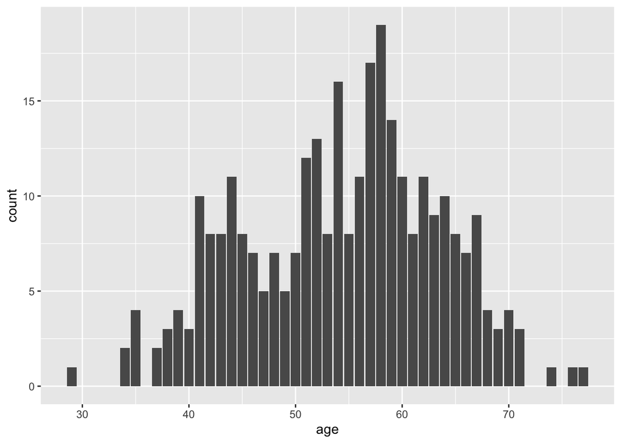

```r
ggplot(data=heart_disease,
       aes(x=age))+
  geom_histogram(stat="count")
```

Histogram of age is fairly normally distributed and indicates that majority of patients will fall between 40 and 66. It is rare for the younger population to experience chest pain.

What do we do here? I think we need to use a classification tool (machine learning) to understand which features are most significant in identifying heart disease.

```r
table(heart_disease$target)
```

```
##
##   0   1
## 138 165
```

```r
# Data Partition
set.seed(33) # My favourite number
samp <- sample(2, nrow(heart_disease), replace=TRUE, prob=c(0.7,0.3))
training_data <- heart_disease[samp==1,] # Training with 70% of our dataset
testing_data <- heart_disease[samp==2,] # Testing with 30% of our dataset

# Random Forest
rf <- randomForest(target~., data=training_data)
print(rf)
```

```
##
## Call:
##  randomForest(formula = target ~ ., data = training_data)
##                Type of random forest: classification
##                      Number of trees: 500
## No. of variables tried at each split: 3
##
##         OOB estimate of  error rate: 18.4%
## Confusion matrix:
##    0  1 class.error
## 0 79 19   0.1938776
## 1 20 94   0.1754386
```

```r
attributes(rf)
```

```
## $names
##  [1] "call"            "type"            "predicted"
##  [4] "err.rate"        "confusion"       "votes"
##  [7] "oob.times"       "classes"         "importance"
## [10] "importanceSD"    "localImportance" "proximity"
## [13] "ntree"           "mtry"            "forest"
## [16] "y"               "test"            "inbag"
## [19] "terms"
##
## $class
## [1] "randomForest.formula" "randomForest"
```

```r
# Prediction & Confusion Matrix - train data
prediction_1 <- predict(rf, training_data)
confusionMatrix(prediction_1, training_data$target)
```

```
## Confusion Matrix and Statistics
##
##           Reference
## Prediction   0   1
##          0  98   0
##          1   0 114
##
##                Accuracy : 1
##                  95% CI : (0.9828, 1)
##     No Information Rate : 0.5377
##     P-Value [Acc > NIR] : < 2.2e-16
##
##                   Kappa : 1
##
##  Mcnemar's Test P-Value : NA
##
##             Sensitivity : 1.0000
##             Specificity : 1.0000
##          Pos Pred Value : 1.0000
##          Neg Pred Value : 1.0000
##              Prevalence : 0.4623
##          Detection Rate : 0.4623
##    Detection Prevalence : 0.4623
##       Balanced Accuracy : 1.0000
##
##        'Positive' Class : 0
##
```

```r
# Prediction & Confusion Matrix - test data
prediction_2 <- predict(rf, testing_data)
confusionMatrix(prediction_2, testing_data$target)
```

```
## Confusion Matrix and Statistics
##
##           Reference
## Prediction  0  1
##          0 31  6
##          1  9 45
##
##                Accuracy : 0.8352
##                  95% CI : (0.7427, 0.9047)
##     No Information Rate : 0.5604
##     P-Value [Acc > NIR] : 2.472e-08
##
##                   Kappa : 0.6627
##
##  Mcnemar's Test P-Value : 0.6056
##
##             Sensitivity : 0.7750
##             Specificity : 0.8824
##          Pos Pred Value : 0.8378
##          Neg Pred Value : 0.8333
##              Prevalence : 0.4396
##          Detection Rate : 0.3407
##    Detection Prevalence : 0.4066
##       Balanced Accuracy : 0.8287
##
##        'Positive' Class : 0
##
```

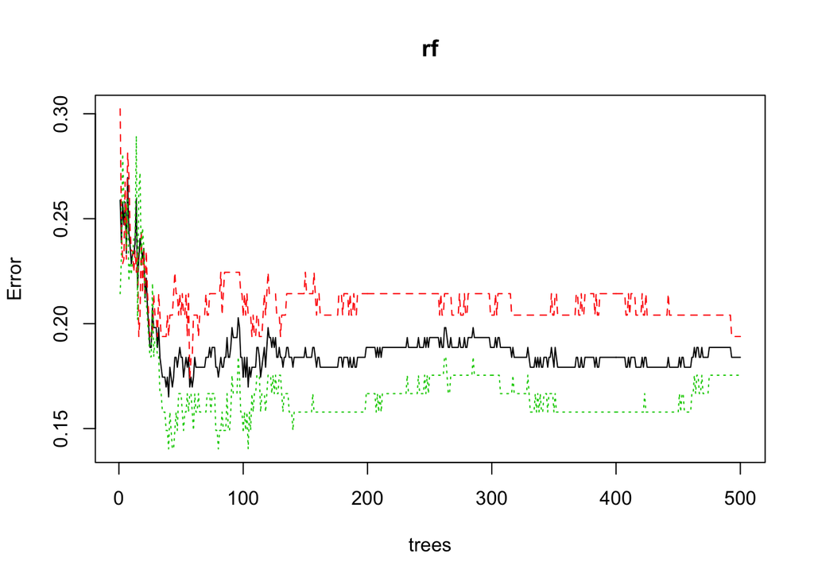

```r
# Error rate
plot(rf)
```

```
## mtry = 3  OOB error = 17.92%
## Searching left ...
## mtry = 6     OOB error = 21.23%
## -0.1842105 0.05
## Searching right ...
## mtry = 1     OOB error = 18.87%
## -0.05263158 0.05
```

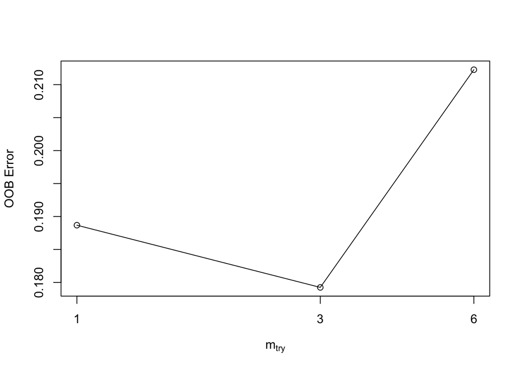

```r
# Tune mtry
training_data$target <- as.factor(training_data$target)
training_data <- as.data.frame(training_data)
t <- tuneRF(training_data[,-14], training_data[,14],
             stepFactor=0.5,
             plot=TRUE,
             ntreeTry=500,
             trace=TRUE,
             improve=0.05)
```

```r
# Random Forest Version 2
rf <- randomForest(target~., data=training_data,
                   ntree = 500,
                   mtry = 3,
                   importance = TRUE,
                   proximity = TRUE)
print(rf)
```

```
##
## Call:
##  randomForest(formula = target ~ ., data = training_data, ntree = 500,      mtry = 3, importance = TRUE, proximity = TRUE)
##                Type of random forest: classification
##                      Number of trees: 500
## No. of variables tried at each split: 3
##
##         OOB estimate of  error rate: 19.34%
## Confusion matrix:
##    0  1 class.error
## 0 77 21   0.2142857
## 1 20 94   0.1754386
```

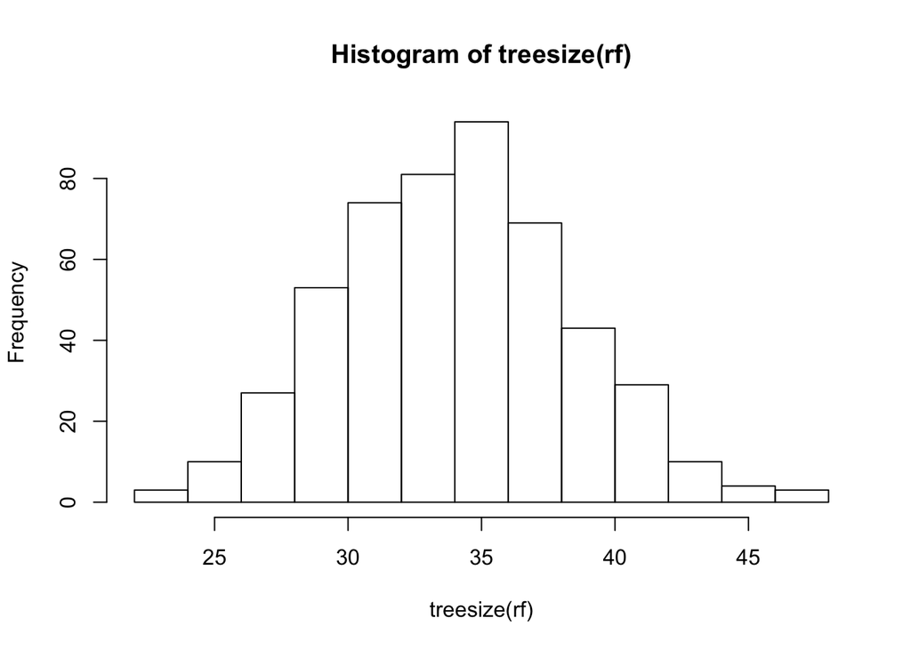

```r
# No. of Tree Nodes
hist(treesize(rf))
```

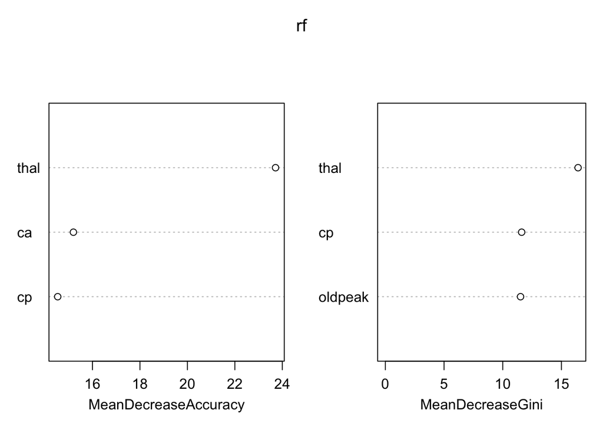

```r
# Variable Importance
varImpPlot(rf,
           n.var = 3)
```

```r
importance(rf)
```

```
##                   0           1 MeanDecreaseAccuracy MeanDecreaseGini
## age       3.2736528  3.88307498            5.1475969         8.656350
## sex       4.4486474  8.05333908            9.0057690         2.531687
## cp       14.1923897  7.30146708           14.5345517        11.611285
## trestbps  1.2296417  1.10487152            1.5954937         6.877085
## chol     -2.6303388  5.69288066            2.4755852         8.259730
## fbs      -0.9110524  1.02142098            0.1069364         1.061680
## restecg   2.7643407 -0.03960937            1.9016761         1.839547
## thalach   7.0095828  5.15467600            8.6049884        11.176270
## exang     8.5389834  3.65099628            8.0954732         6.274120
## oldpeak   8.8384282  9.41248559           12.4367039        11.516137
## slope     7.6075447  6.57255383            9.8562740         6.980715
## ca       11.5757448 11.55875009           15.1960623        10.750812
## thal     19.4390336 17.61915783           23.7150159        16.416000
```

```r
varUsed(rf)
```

```
##  [1] 2026  613 1247 1929 2103  411  698 2138  675 1757  883 1148 1126
```

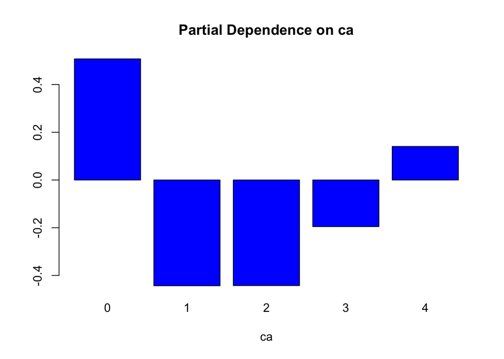

```r
# Partial Dependence Plot
partialPlot(rf, training_data, ca, "1")
```

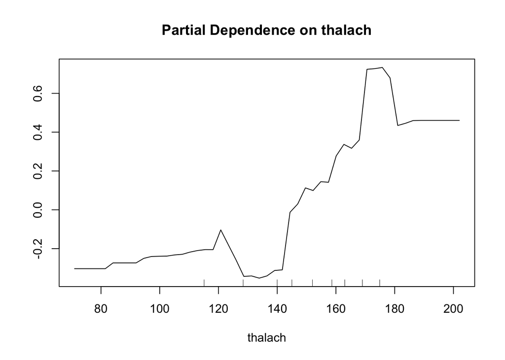

```r
partialPlot(rf, training_data, thalach, "1")
```

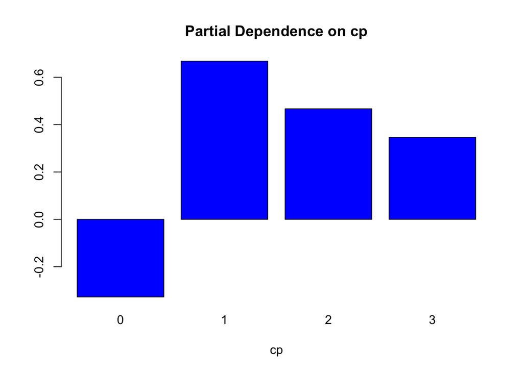

```r
partialPlot(rf, training_data, cp, "1")
```

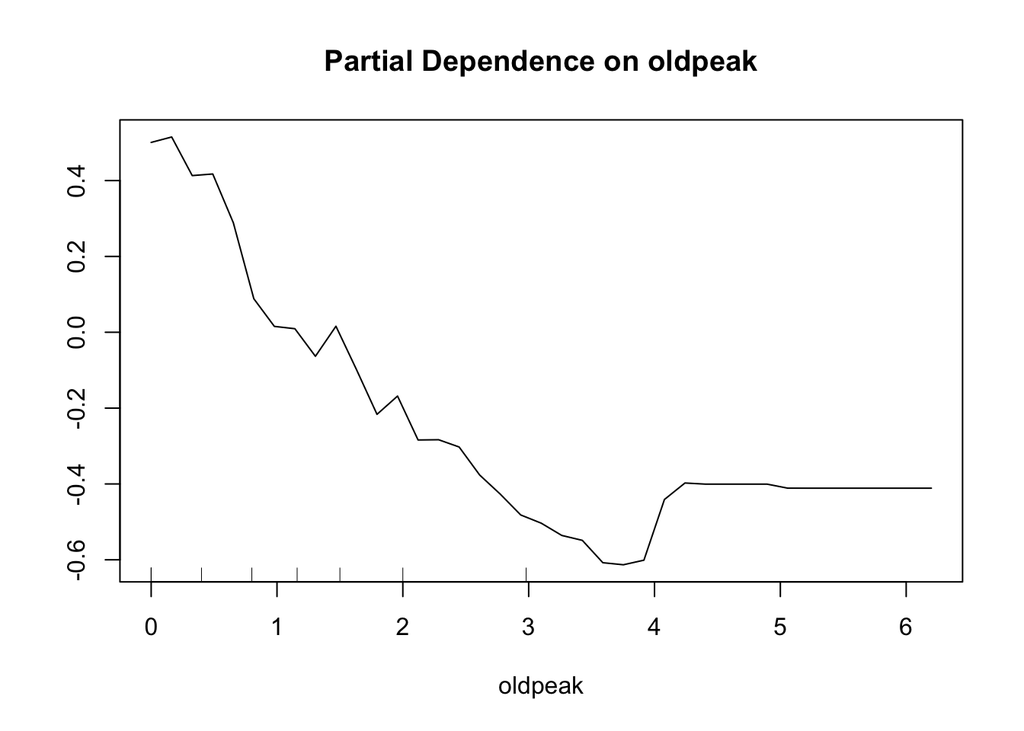

```r
partialPlot(rf, training_data, oldpeak, "1")
```

How does the random forest algorithm work? (1) Draw ntree bootstrap samples (2) For each ntree bootstrap sample, grow unpruned tree by choosing best split based on a random sample of mtry predictors at each node (3) Predict new data using majority votes for classification and average for regression based on mtry trees Reference: https://www.youtube.com/watch?v=dJclNIN-TPo

# Random Forest

Derived from our model: ntree = 500 mtry: the number of variables available for splitting at each tree node = 3 (which is often square root of the number of features) estimated accuracy = 1 - 0.184 = 0.816 (note: this is oob error which is prediction error using data not in bootstrap sample) confusion matrix: very close error percentage when predicting whether target has heart disease n=0,1

# Prediction & Confusion Matrix - training data

The accuracy is based on the ‘training’ data which was already observed by the random forest model.

# Prediction & Confusion Matrix - testing data

The accuracy has dropped from 100% to 83.52% (the random forest model has not observed the test data before) which is a more accurate accuracy assessment of the model. If we put this into context, approximately 1/5 classifications will be incorrect.

The confidence interval has a moderate spread (0.7427, 0.9047).

Sensitivity and specificity are two fundamental aspects of machine learning. (a) sensitivity: “the proportion of actual positive cases that got predicted as positive”, also known as, false negative rate. (b) specificity: “the proportion of actual negatives”, also known as, false positive rate. These two measures are used to plot the ROC curve in which the AUC determines the model’s performance.

# Error Rate

# Tune Model and Error Rate

Seems like we can’t tune the model to reduce the error rate. Confusion matrix indicates that our model is able to predict heart disease better than non-heart disease.

# No. of Tree Nodes

# Variable Importance

We have two graphs here: (a) Left depicts the decrease in accuracy if the variable was excluded (b) Right depicts the decrease in Gini Impurity (the probability that the model classifies the datapoint incorrectly) of a node if the variable was excluded.

Reference: https://towardsdatascience.com/an-implementation-and-explanation-of-the-random-forest-in-python-77bf308a9b76

# Partial Dependence Plots

cp (chest pain type): when chest pain is 1, 2, or 3, the model is more likely to classify as heart disease. Typical angina (catergorised as 0) is associated with the lack of blood and/or oxygen to the haert typically caused my blockage or plaque buildup but does not increase the risk of heart attack. On the other hand, atypical angina, non-anginal pain, and asymptomatic patients are much more likely to get a heart attack as it denotes something more severe.

thalach (maximum heart rate): the model suggests that patients with 145 to 200 bpm are more likely to have a heart attack - but doesnt a high maximum heart rate indicate a healthy heart? Tachycardia is a common disease when the heart beat is too fast or irregular which increases the risk of heart disease. This is just an assumption but this may be a possible explanation.

ca (major vessels colored by fluoroscopy): the model predicted heart disease when ca was 0 and 4, and not heart disease when ca was 1, 2 and 3. Fluroscopy is an imaging technique to obtain real time movement of the interior body so medical professionals can examine the movement of blood. I could not find information regarding the respective major vessels.

oldpeak (ST depression induced by exercise relative to rest): ST depression is a common symptom across various heart diseases; typical angina included. This means ST depression can be representative of both serious and non-serious heart diseases. Our model classifies very low levels (0-1) of ST depression as heart disease, and the model is more likely to categorise non-heart disease as ST depression increases.

# SUMMARY:

This model has a 83.52% accuracy rate when predicting heart disease in patients which is risky if applied in the real world; a thereotical 1/5 misdiagnoses. However, the random forest model did help us understand which variables it deemed important, and as a result, help guide us in some direction.

The medical world is extensive and every case is almost different. Next time, we need more data for machine learning, possibly more variables, and a whole ton more knowledge.